# Modelo de una zapata: cimentación sobre un deposito de suelo estratificado

**Integrantes:**

- Javier Everardo Quintero Jaramillo
- Sebastian Cañas Jimenez
- Oscar Rincón Cardeño

Para las propiedades de los materiales dadas en el notebook y para zapata:

- Para el sistema propuesto dibujar el diagrama de cuerpo libre de la cimentación.
- Llevar la combinación de cargas propuestas a valores que produzcan la falla inminente del depósito de suelo de manera que se rompa el equilibrio.

A continuación se importan las librerías que se utilizan en este notebook

```python
# Esta línea asegura que los gráficos que crees se muestren en el cuaderno sin necesidad de llamar a plt.show() cada vez.
%matplotlib inline

# Importando las bibliotecas necesarias

# NumPy es una biblioteca para el lenguaje de programación Python, que añade soporte para grandes matrices y arreglos multidimensionales,
# junto con una gran colección de funciones matemáticas de alto nivel para operar en estos arreglos.
import numpy as np

# Matplotlib es una biblioteca de gráficos para el lenguaje de programación Python y su extensión de matemáticas numéricas NumPy.
# Proporciona una API orientada a objetos para incrustar gráficos en aplicaciones usando kits de herramientas GUI de propósito general como Tkinter, wxPython, Qt, o GTK.
import matplotlib.pyplot as plt

# solidspy.postprocesor es un módulo de la biblioteca SolidSpy, que es un análisis de elementos finitos simple en Python.
# Este módulo contiene rutinas para el post-procesamiento de los resultados.
import solidspy.postprocesor as pos

# aux_functions es un módulo definido por el usuario. Parece contener rutinas externas creadas para la automatización de tareas.
import aux_functions as aux

# pandas es una biblioteca de software escrita para el lenguaje de programación Python para la manipulación y análisis de datos.
# En particular, ofrece estructuras de datos y operaciones para manipular tablas numéricas y series de tiempo.
import pandas as pd

from IPython.display import display, Image


import warnings
warnings.filterwarnings('ignore')
```

Aquí está el código de la función modelos que selecciona el modelo a utilizar basándose en el parámetro id_model y devuelve los parámetros correspondientes:

```python
def modelos(P1, P2, V1, V2, id_model):
    """
    Esta función selecciona el modelo a utilizar basándose en el parámetro id_model y devuelve los parámetros correspondientes.

    Parámetros:
    P1, P2, V1, V2: Parámetros de carga
    id_model: Identificador del modelo a utilizar (0 para zapata, 1 para 1 pilote, cualquier otro valor para 2 pilotes)

    Devuelve:
    nodes, mats, elements, loads, UG, UC, S_nodes, E_nodes, eles: Parámetros correspondientes al modelo seleccionado
    """

    # Selección del modelo
    if id_model == 0:  # Condición para el modelo zapata
        nodes, mats, elements, loads, UG, UC, S_nodes, E_nodes, eles = aux.zapata(P1, P2, V1, V2)
    elif id_model == 1:  # Condición para el modelo 1 pilote
        nodes, mats, elements, loads, UG, UC, S_nodes, E_nodes, eles = aux.pilote_1(P1, P2, V1, V2)
    else:  # Condición para el modelo 2 pilotes
        nodes, mats, elements, loads, UG, UC, S_nodes, E_nodes, eles = aux.pilote_2(P1, P2, V1, V2)

    # Devuelve los parámetros
    return nodes, mats, elements, loads, UG, UC, S_nodes, E_nodes, eles
```

En la siguiente celda se propone el modelo 0, correspondiente a una zapata.

```python
# Elige el modelo (0: Zapata, 1: 1 pilote, 2: 2 pilotes)
id_model = 0
```

Se incluye el codigo con la combinación de cargas obtenido en el notebook 01.

```python
# Define las cargas en tf (tonelada-fuerza) y tf*m (tonelada-fuerza metro)
P = 0.0  # tf
V = 1.5  # tf
M = 0.0  # tf*m

# Calcula la magnitud del vector
magnitud = np.sqrt(P**2 + M**2 + V**2)

# Imprime el resultado
print("La magnitud del vector es:", magnitud, "tf")
```

```
La magnitud del vector es: 1.5 tf
```

Este código calcula e imprime las cargas resultantes en cada punto de aplicación en toneladas-fuerza (tf).

```python
# Calcula las cargas resultantes en cada punto de aplicación en tf
P1 = -2 * M + P / 2 # tf
P2 = 2 * M + P / 2 # tf
V1 = V / 2 # tf
V2 = V / 2 # tf

# Imprime las cargas resultantes
print(f"P1 = {P1} tf")
print(f"P2 = {P2} tf")
print(f"V1 = {V1} tf")
print(f"V2 = {V2} tf")
```

```
P1 = 0.0 tf
P2 = 0.0 tf
V1 = 0.75 tf
V2 = 0.75 tf
```

Se ejecuta el modelo y obtienen los parámetros

```python
nodes, mats, elements, loads, UG, UC, S_nodes, E_nodes, eles = modelos(P1, P2, V1, V2, id_model)
```

```python
# Extrayendo tensiones

# Extrae la tensión normal horizontal (sig_x) de la primera columna de S_nodes
sig_x = S_nodes[:, 0]

# Extrae la tensión normal vertical (sig_y) de la segunda columna de S_nodes
sig_y = S_nodes[:, 1]

# Extrae la tensión de corte (sig_xy) de la tercera columna de S_nodes
sig_xy = S_nodes[:, 2]

# Apila verticalmente los elementos de diferentes capas usando la función vstack de numpy
# Cada elemento corresponde a una capa diferente de la estructura del suelo
els = np.vstack((
    eles[1],  # Semi-espacio
    eles[2],  # Estrato 5
    eles[3],  # Estrato 4
    eles[4],  # Estrato 3
    eles[5],  # Estrato 2
    eles[6],  # Estrato 1
    eles[7]   # Cimentación
))
```

A continuación se calculan las tensiones principales y cortantes máximos que serán comparadas con los valores de resistencia a compresión y corte.

```python
sig_x  = S_nodes[: , 0]
sig_y  = S_nodes[: , 1]
sig_xy = S_nodes[: , 2]
sig_1, sig_2, dir_1, dir_2 = pos.principal_dirs(S_nodes)
TAO = (np.abs(sig_1 - sig_2))/2
```

Para el sistema propuesto se grafica la distribución de tensiones de la cimentación.

```
(31.0, 33.0)
```

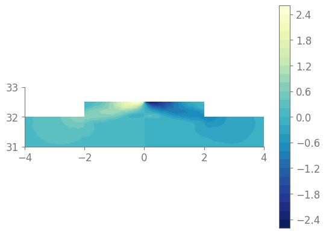

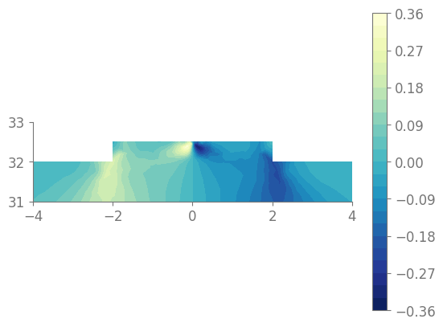

```python
pos.plot_node_field(sig_x , nodes, els, plt_type="contourf", levels= 24)
plt.xlim([-4,4])
plt.ylim([31,33])
pos.plot_node_field(sig_y , nodes, els, plt_type="contourf", levels= 24)
plt.xlim([-4,4])
plt.ylim([31,33])
```

A continuación se presenta un diagrama de cuerpo libre de la zapata.

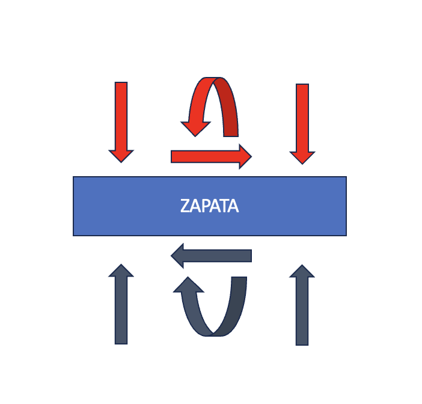

```python
display(Image(filename='img/diagrama_zapata.png'))
```

Ahora se repite el procedimiento con valores que producen la falla del deposito de suelo al romper el equilibrio del sistema. Para esto se reescalan $\times$ 10 las cargas obtenidas. Se observa como el color purpura alcanza la zona del estrato 1 para la tensión de corte máxima.

```
La magnitud del vector es: 15.0 tf
P1 = 0.0 tf
P2 = 0.0 tf
V1 = 7.5 tf
V2 = 7.5 tf
```

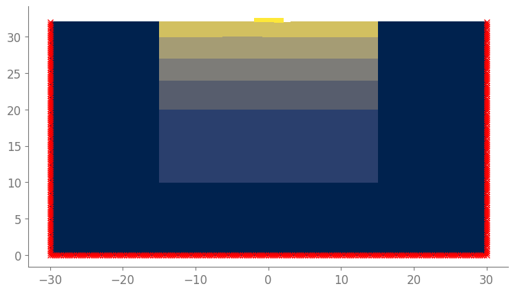

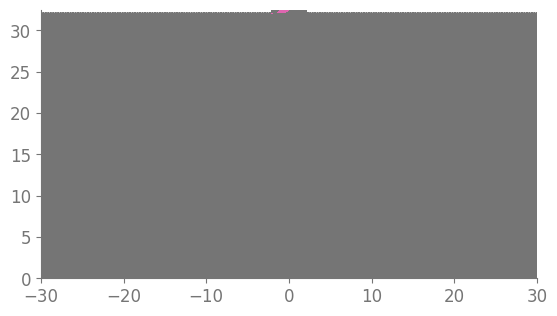

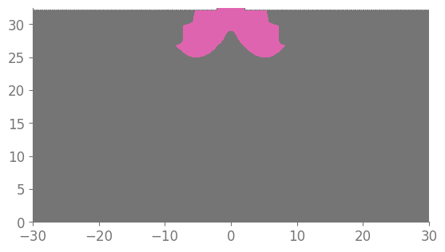

```python
#factor de reescalamiento de las cargas
f_0 = 10

# Define las cargas en tf (tonelada-fuerza) y tf*m (tonelada-fuerza metro)
P = f_0*0.0  # tf
V = f_0*1.5  # tf
M = f_0*0.0  # tf*m

# Calcula la magnitud del vector
magnitud = np.sqrt(P**2 + M**2 + V**2)

# Imprime el resultado
print("La magnitud del vector es:", magnitud, "tf")


# Calcula las cargas resultantes en cada punto de aplicación en tf
P1 = -2 * M + P / 2 # tf
P2 = 2 * M + P / 2 # tf
V1 = V / 2 # tf
V2 = V / 2 # tf

# Imprime las cargas resultantes
print(f"P1 = {P1} tf")
print(f"P2 = {P2} tf")
print(f"V1 = {V1} tf")
print(f"V2 = {V2} tf")


nodes, mats, elements, loads, UG, UC, S_nodes, E_nodes, eles = modelos(P1, P2, V1, V2, id_model)


sig_1, sig_2, dir_1, dir_2 = pos.principal_dirs(S_nodes)
TAO = (np.abs(sig_1 - sig_2))/2

# Apila verticalmente los elementos de diferentes capas usando la función vstack de numpy
# Cada elemento corresponde a una capa diferente de la estructura del suelo
els = np.vstack((
    eles[1],  # Semi-espacio
    eles[2],  # Estrato 5
    eles[3],  # Estrato 4
    eles[4],  # Estrato 3
    eles[5],  # Estrato 2
    eles[6],  # Estrato 1
    eles[7]   # Cimentación
))

aux.deformacionFill(nodes , elements , UC , factor = 1.0 , cmap='cividis')
ref_val=-9.58
aux.filtered(nodes,els , sig_1, ref_val)
ref_val=0.50
aux.filtered(nodes,els , TAO, ref_val)
```